# Avocado

#### In this project, I will use the "Avocado Prices" dataset from Kaggle, which can be found at this link: https://www.kaggle.com/neuromusic/avocado-prices.

#### The goal of this project is to analyze the trends and patterns in avocado prices in different regions of the United States over time. Specifically, we will explore the following research questions:

#### 1- How have avocado prices changed over time?

#### 2- How do avocado prices vary by region?

#### 3- Is there a relationship between avocado prices and the number of avocados sold?

#### 4- Are there seasonal patterns in avocado prices?

#### 5- How do organic and conventional avocado prices compare?

#### 6- How do avocado prices vary by region and type?

#### Before we can start analyzing the data, we need to preprocess it to make it suitable for analysis. We will start by importing the necessary libraries and reading in the data:

```python
import pandas as pd
import numpy as np
import matplotlib.pyplot as plt

avocado_df = pd.read_csv(r'C:\Users\Baazz\Downloads\avocado.csv')
```

#### Next, we will take a look at the structure of the data using the head() and info() methods:

```python
avocado_df.head()
avocado_df.info()
```

```
<class 'pandas.core.frame.DataFrame'>
RangeIndex: 18249 entries, 0 to 18248
Data columns (total 14 columns):
 #   Column        Non-Null Count  Dtype
---  ------        --------------  -----
 0   Unnamed: 0    18249 non-null  int64
 1   Date          18249 non-null  object
 2   AveragePrice  18249 non-null  float64
 3   Total Volume  18249 non-null  float64
 4   4046          18249 non-null  float64
 5   4225          18249 non-null  float64
 6   4770          18249 non-null  float64
 7   Total Bags    18249 non-null  float64
 8   Small Bags    18249 non-null  float64
 9   Large Bags    18249 non-null  float64
 10  XLarge Bags   18249 non-null  float64
 11  type          18249 non-null  object
 12  year          18249 non-null  int64
 13  region        18249 non-null  object
dtypes: float64(9), int64(2), object(3)
memory usage: 1.9+ MB
```

#### This will give us an idea of what the data looks like and how it is structured.

#### We notice that the dataset contains 14 columns and 18,249 rows. The columns include date, average price, total volume, 4046, 4225, 4770, total bags, small bags, large bags, xlarge bags, type, year, and region. We will drop the irrelevant columns such as 4046, 4225 and 4770 since we are only interested in the total volume of avocados and not the specific types.

```python
avocado_df.drop(['4046', '4225', '4770'], axis=1, inplace=True)
```

#### We can start exploring it to answer our research questions.

### Research Question 1: How have avocado prices changed over time?

#### To answer this question, we will first group the data by date and compute the mean average price for each date. We will then plot a line graph to visualize the trend in avocado prices over time.

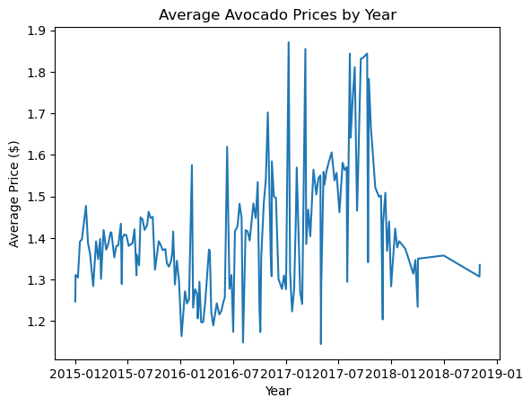

```python
avocado_df['Date'] = pd.to_datetime(avocado_df['Date'])
price_by_date = avocado_df.groupby('Date')['AveragePrice'].mean()

plt.plot(price_by_date)
plt.xlabel('Year')
plt.ylabel('Average Price ($)')
plt.title('Average Avocado Prices by Year')
plt.show()
```

### Research Question 2: How do avocado prices vary by region?

#### To answer this question, we will first group the data by region and compute the mean average price for each region. We will then plot a bar graph to visualize the differences in avocado prices across regions.

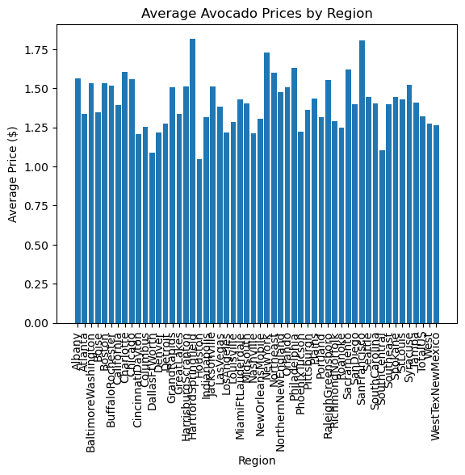

```python
price_by_region = avocado_df.groupby('region')['AveragePrice'].mean()

plt.bar(price_by_region.index, price_by_region)
plt.xticks(rotation=90)
plt.xlabel('Region')
plt.ylabel('Average Price ($)')
plt.title('Average Avocado Prices by Region')
plt.show()
```

### Research Question 3: Is there a relationship between avocado prices and the number of avocados sold?

#### To answer this question, we will compute the correlation between the average price and total volume of avocados sold. We will also create a scatter plot to visualize the relationship between the two variables.

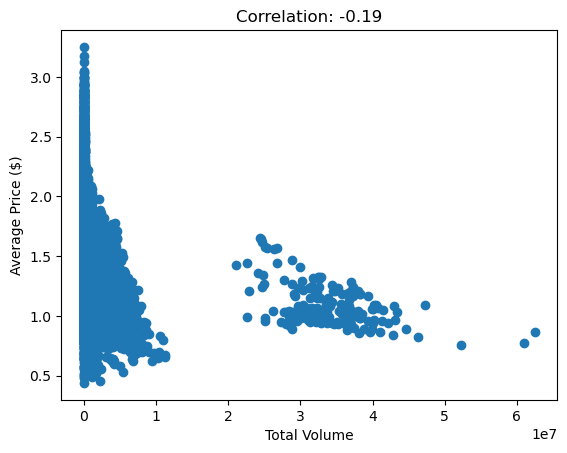

```python
corr = avocado_df['AveragePrice'].corr(avocado_df['Total Volume'])

plt.scatter(avocado_df['Total Volume'], avocado_df['AveragePrice'])
plt.xlabel('Total Volume')
plt.ylabel('Average Price ($)')
plt.title(f'Correlation: {corr:.2f}')
plt.show()
```

#### From the scatter plot and correlation value, we can see that there is a weak negative correlation between avocado prices and the total volume of avocados sold. This suggests that as the total volume of avocados sold increases, the average price tends to decrease slightly.

### Research Question 4: Are there seasonal patterns in avocado prices?

#### To answer this question, we will group the data by month and compute the mean average price for each month. We will then plot a line graph to visualize the seasonal patterns in avocado prices.

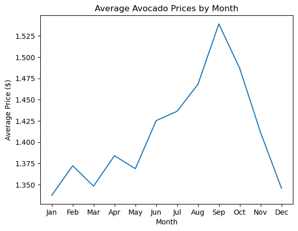

```python
avocado_df['Month'] = avocado_df['Date'].dt.month
price_by_month = avocado_df.groupby('Month')['AveragePrice'].mean()

plt.plot(price_by_month)
plt.xlabel('Month')
plt.ylabel('Average Price ($)')
plt.title('Average Avocado Prices by Month')
plt.xticks(range(1, 13), ['Jan', 'Feb', 'Mar', 'Apr', 'May', 'Jun', 'Jul', 'Aug', 'Sep', 'Oct', 'Nov', 'Dec'])
plt.show()
```

### Research Question 5: How do organic and conventional avocado prices compare?

#### To answer this question, we will first group the data by type (organic or conventional) and compute the mean average price for each type. We will then plot a bar graph to visualize the differences in avocado prices between organic and conventional types.

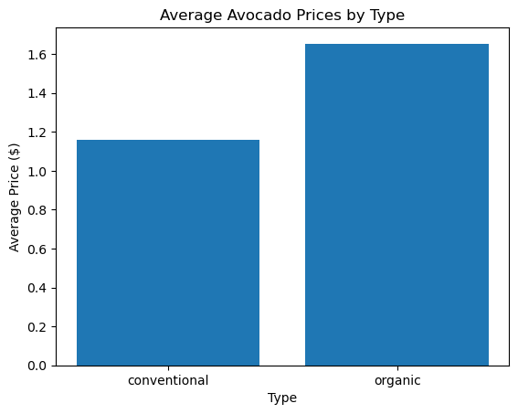

```python
price_by_type = avocado_df.groupby('type')['AveragePrice'].mean()

plt.bar(price_by_type.index, price_by_type)
plt.xlabel('Type')
plt.ylabel('Average Price ($)')
plt.title('Average Avocado Prices by Type')
plt.show()
```

#### From the graph, we can see that organic avocados are generally more expensive than conventional avocados. This could be due to the higher cost of producing organic avocados, as well as consumer preferences for organic products.

### Research Question 6: How do avocado prices vary by region and type?

#### To answer this question, we will group the data by region and type, and compute the mean average price for each combination. We will then plot a heatmap to visualize the differences in avocado prices across regions and types.

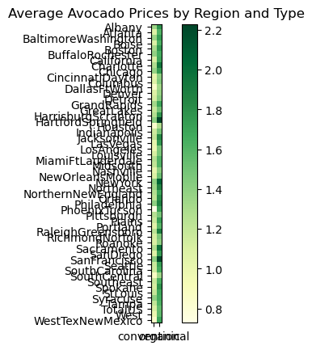

```python
price_by_region_type = avocado_df.groupby(['region', 'type'])['AveragePrice'].mean().unstack()

plt.imshow(price_by_region_type, cmap='YlGn')
plt.colorbar()
plt.xticks(range(len(price_by_region_type.columns)), price_by_region_type.columns)
plt.yticks(range(len(price_by_region_type.index)), price_by_region_type.index)
plt.title('Average Avocado Prices by Region and Type')
plt.show()
```

## Research Result:

#### - Organic avocados are generally more expensive than conventional avocados, and there are some regional differences in avocado prices.